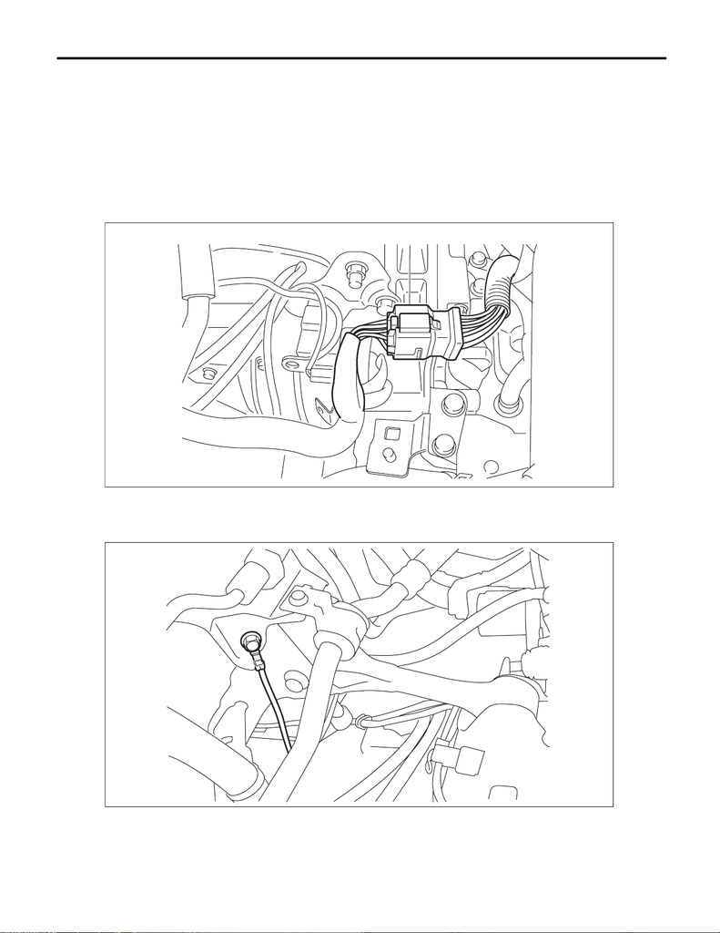

CS-94

MT Gear Select Cable

CONTROL SYSTEMS

9. MT Gear Select Cable

A: REMOVAL

CAUTION:

Always use new MT gear select cable if the cable is removed from selector lever COMPL of transmis-

sion side.

1) Disconnect the ground terminal from battery sensor. <Ref. to NT-5, BATTERY, NOTE, Note.>

2) Remove the air intake duct. <Ref. to IN(w/o STI)-22, REMOVAL, Air Intake Duct.>

3) Remove the intercooler and the intercooler stay. <Ref. to IN(w/o STI)-38, REMOVAL, Intercooler.>

4) Disconnect the engine harness connector.

5) Disconnect the transmission radio ground cord terminal.

(A) Engine harness connectors

CS-01783

(A)

CS-01461

15WRX_STI_US_EN.book 94 ページ ２０１５年２月１３日 金曜日 午前１１時２０分

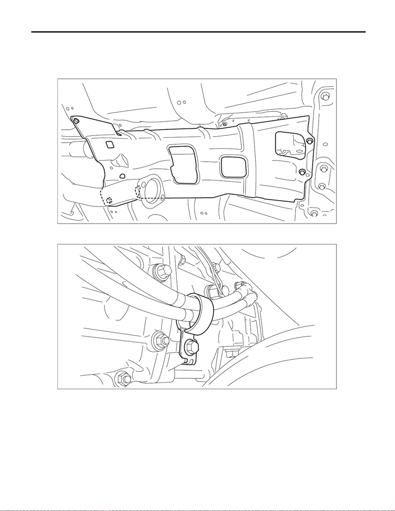

CS-95

MT Gear Select Cable

CONTROL SYSTEMS

6) Remove the pitching stopper. <Ref. to 6MT(TY85)-29, PITCHING STOPPER, REMOVAL, Transmission

Mounting System.>

7) Lift up the vehicle.

8) Remove the center exhaust pipe (rear). <Ref. to EX(w/o STI)-35, REMOVAL, Center Exhaust Pipe.>

9) Remove the center exhaust cover.

10) Remove the propeller shaft. <Ref. to DS-12, REMOVAL, Propeller Shaft.>

11) Remove the cable clamp.

(A) Cable clamp

CS-01671

CS-01673

(A)

15WRX_STI_US_EN.book 95 ページ ２０１５年２月１３日 金曜日 午前１１時２０分

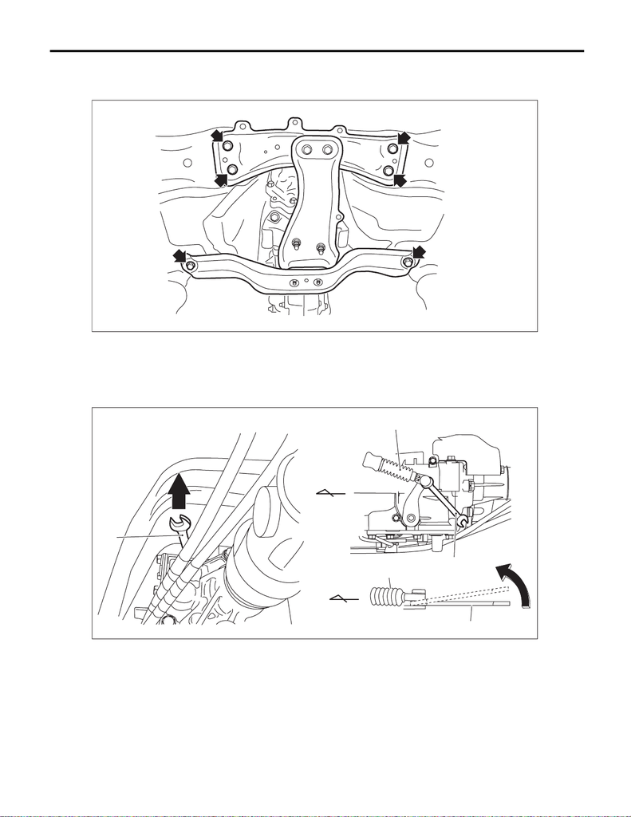

CS-96

MT Gear Select Cable

CONTROL SYSTEMS

12) Place the transmission jack under the transmission.

13) Remove the mounting bolt of front crossmember and rear crossmember, and lower the transmission ap-

prox. 100 mm (4 in).

14) Insert a spanner between the selector lever COMPL and the MT gear select cable, and remove the MT

gear select cable by raising the handle.

NOTE:

• Use a spanner with 11 to 13 in size.

• The thickness of the spanner must not exceed 6 mm (0.2 in).

(A) MT gear select cable (B) Spanner (C) Forward

MT-03182

CS-01160

(A)

(B)

(B)

(A)

(B)

(C)

(C)

15WRX_STI_US_EN.book 96 ページ ２０１５年２月１３日 金曜日 午前１１時２０分

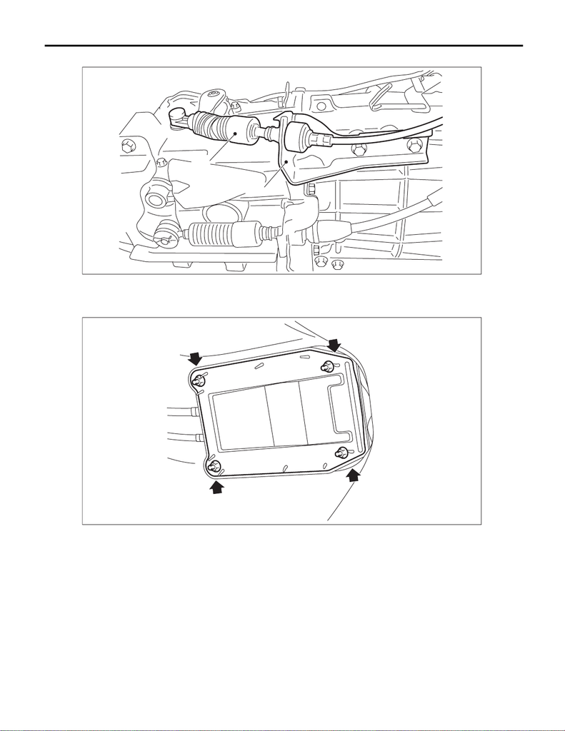

CS-97

MT Gear Select Cable

CONTROL SYSTEMS

15) Remove the MT gear select cable and select bracket as a single unit.

16) Remove the cable cover plate.

(A) MT gear select cable (B) Select bracket

CS-01559

(B)

(A)

CS-01848

15WRX_STI_US_EN.book 97 ページ ２０１５年２月１３日 金曜日 午前１１時２０分

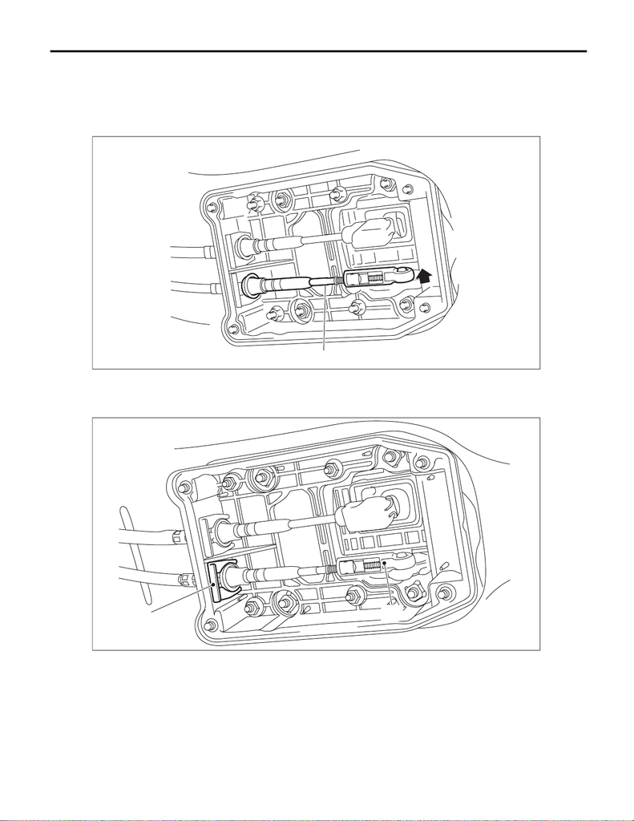

CS-98

MT Gear Select Cable

CONTROL SYSTEMS

17) Disconnect the MT gear select cable.

CAUTION:

Be careful not to deform the cable inner.

NOTE:

Push the MT gear select cable in the direction of arrow, and remove it.

18) Remove the clamp.

(A) MT gear select cable

(A) Clamp (B) MT gear select cable

CS-01454

(A)

CS-01689

(A)

(B)

15WRX_STI_US_EN.book 98 ページ ２０１５年２月１３日 金曜日 午前１１時２０分

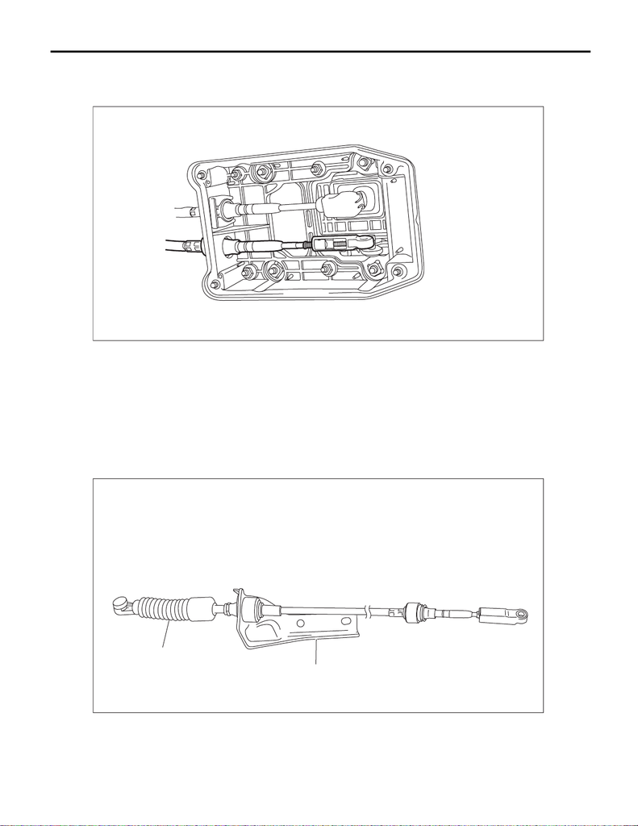

CS-99

MT Gear Select Cable

CONTROL SYSTEMS

19) Pull out the MT gear select cable.

CAUTION:

Do not bend the MT gear select cable sharply.

B: INSTALLATION

CAUTION:

• Always use new MT gear select cable if the cable is removed from selector lever COMPL of trans-

mission side.

• Do not bend the MT gear select cable sharply.

• Do not twist the inner cable excessively.

1) Remove the MT gear select cable from the select bracket.

CAUTION:

Check for assembling position before removing the MT gear select cable from the select bracket.

(A) MT gear select cable (B) Select bracket

CS-01458

CS-01250

(A)

(B)

15WRX_STI_US_EN.book 99 ページ ２０１５年２月１３日 金曜日 午前１１時２０分

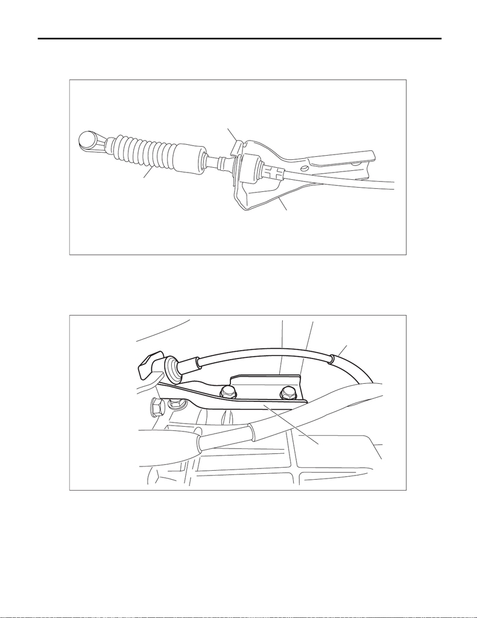

CS-100

MT Gear Select Cable

CONTROL SYSTEMS

2) Set to the new MT gear select cable to the select bracket and secure it with the clamp.

CAUTION:

Be careful not to mistake the MT gear select cable installing direction.

3) Install the MT gear select cable and select bracket as a single unit.

Tightening torque:

18 N·m (1.8 kgf-m, 13.3 ft-lb)

(A) MT gear select cable (B) Select bracket (C) Clamp

(A) Select bracket (B) MT gear select cable

CS-01165

(C)

(B)

(A)

CS-01161

(B)

(A)

15WRX_STI_US_EN.book 100 ページ ２０１５年２月１３日 金曜日 午前１１時２０分

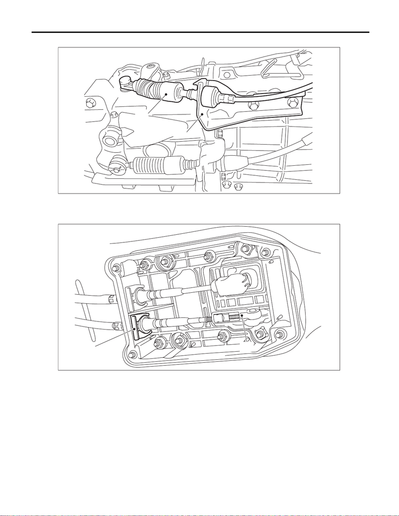

CS-101

MT Gear Select Cable

CONTROL SYSTEMS

4) Install the MT gear select cable to the select lever COMPL.

5) Insert the MT gear select cable into cable cover assembly, and install the clamp.

(A) MT gear select cable (B) Select bracket

(A) Clamp (B) MT gear select cable

CS-01559

(B)

(A)

CS-01689

(A)

(B)

15WRX_STI_US_EN.book 101 ページ ２０１５年２月１３日 金曜日 午前１１時２０分

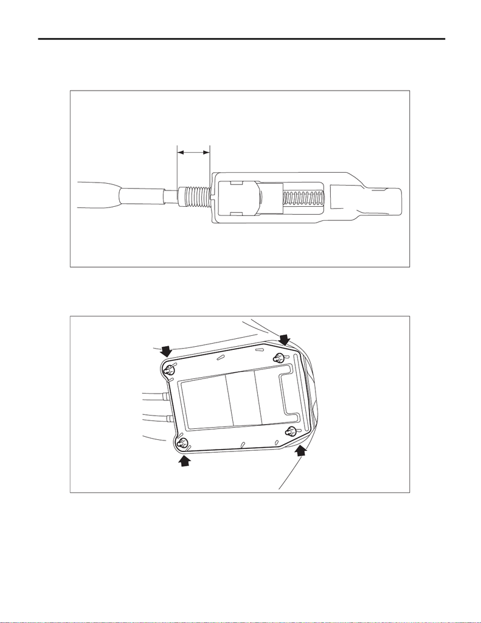

CS-102

MT Gear Select Cable

CONTROL SYSTEMS

6) Measure the exposed length (a) of MT gear select cable. If the value is out of specification, adjust the MT

gear select cable. <Ref. to CS-105, ADJUSTMENT, MT Gear Select Cable.>

Exposed length (a) of MT gear select cable:

Specification: 11 mm (0.4 in)

7) Connect the MT gear select cable.

8) Attach the cable cover plate.

Tightening torque:

7.5 N·m (0.8 kgf-m, 5.5 ft-lb)

CS-01167

(a)

CS-01848

15WRX_STI_US_EN.book 102 ページ ２０１５年２月１３日 金曜日 午前１１時２０分

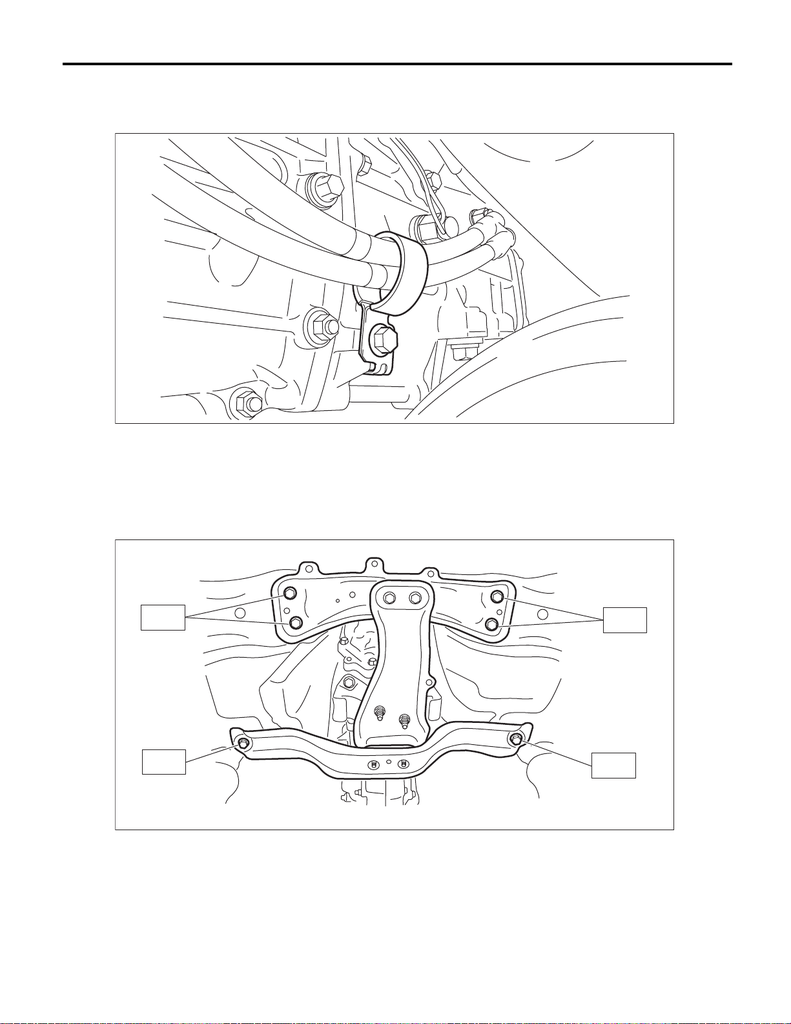

CS-103

MT Gear Select Cable

CONTROL SYSTEMS

9) Insert the MT gear select cable into cable clamp, and install to the transmission.

Tightening torque:

18 N·m (1.8 kgf-m, 13.3 ft-lb)

10) Raise the transmission jack, install the front crossmember and rear crossmember.

Tightening torque:

T1: 70 N·m (7.1 kgf-m, 51.6 ft-lb)

T2: 140 N·m (14.3 kgf-m, 103.3 ft-lb)

11) Take out the transmission jack.

12) Install the propeller shaft. <Ref. to DS-14, INSTALLATION, Propeller Shaft.>

13) Install the center exhaust cover.

Tightening torque:

18 N·m (1.8 kgf-m, 13.3 ft-lb)

14) Install the center exhaust pipe (rear). <Ref. to EX(w/o STI)-41, INSTALLATION, Center Exhaust Pipe.>

15) Lower the vehicle.

(A) Cable clamp

CS-01673

(A)

CS-01849

T1

T1

T2

T2

15WRX_STI_US_EN.book 103 ページ ２０１５年２月１３日 金曜日 午前１１時２０分

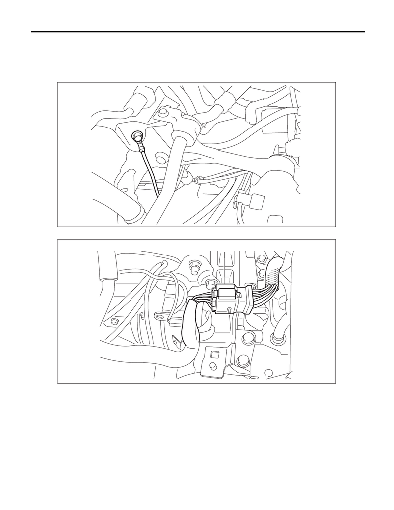

CS-104

MT Gear Select Cable

CONTROL SYSTEMS

16) Install the pitching stopper. <Ref. to 6MT(TY85)-29, PITCHING STOPPER, INSTALLATION, Transmis-

sion Mounting System.>

17) Install the transmission radio ground cord terminal.

Tightening torque:

13 N·m (1.3 kgf-m, 9.6 ft-lb)

18) Connect the engine harness connector.

19) Install the intercooler stay and the intercooler. <Ref. to IN(w/o STI)-41, INSTALLATION, Intercooler.>

20) Install the air intake duct. <Ref. to IN(w/o STI)-22, INSTALLATION, Air Intake Duct.>

21) Connect the ground terminal to battery sensor. <Ref. to NT-5, BATTERY, NOTE, Note.>

22) Adjust the detent of the MT gear shift lever. <Ref. to CS-82, ADJUSTMENT, MT Gear Shift Lever.>

23) Make sure the gears can be shifted accurately into each gear.

(A) Engine harness connectors

CS-01461

CS-01783

(A)

15WRX_STI_US_EN.book 104 ページ ２０１５年２月１３日 金曜日 午前１１時２０分

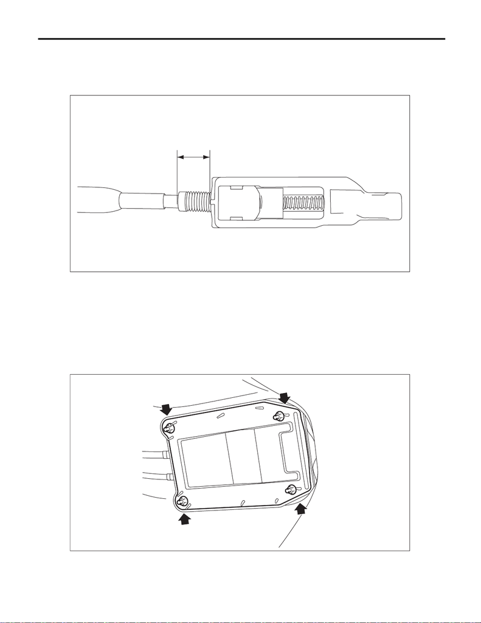

CS-105

MT Gear Select Cable

CONTROL SYSTEMS

C: INSPECTION

1) Check that exposed length (a) of MT gear select cable is within specification.

Exposed length (a) of MT gear select cable:

Specification: 11 mm (0.4 in)

2) If it is not within the specification, perform the adjustment. <Ref. to CS-105, ADJUSTMENT, MT Gear Se-

lect Cable.>

D: ADJUSTMENT

NOTE:

Two persons are required to perform the MT gear select cable adjustment. (Only the step 7) requires two

workers.)

1) Loosen the detent bolt of the MT gear shift lever. <Ref. to CS-82, ADJUSTMENT, MT Gear Shift Lever.>

2) Move the shift lever to the 6th.

3) Remove the cable cover plate.

CS-01167

(a)

CS-01848

15WRX_STI_US_EN.book 105 ページ ２０１５年２月１３日 金曜日 午前１１時２０分

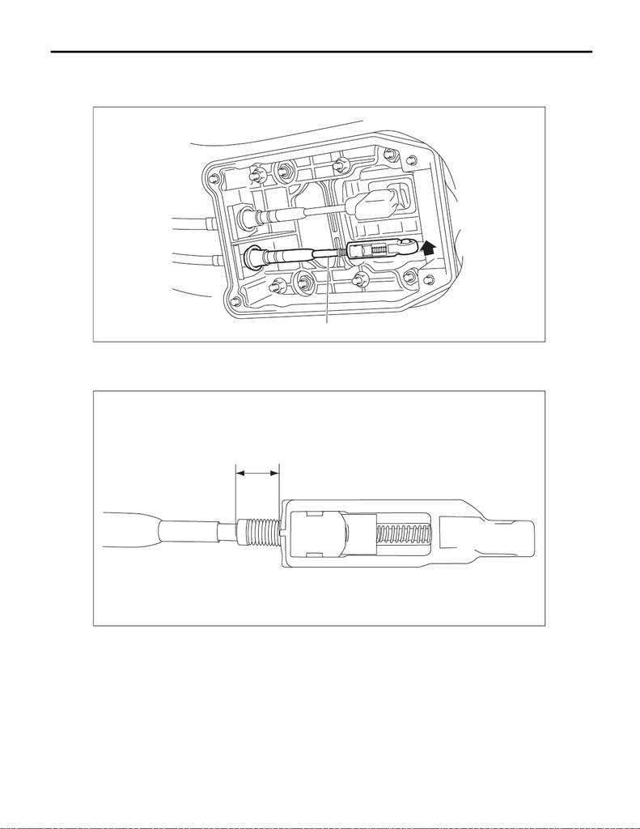

CS-106

MT Gear Select Cable

CONTROL SYSTEMS

4) Disconnect the MT gear select cable.

NOTE:

Push the MT gear select cable in the direction of arrow, and remove it.

5) Measure the exposed length (a) of MT gear select cable.

(A) MT gear select cable

(a) Measurement value

CS-01454

(A)

CS-01167

(a)

15WRX_STI_US_EN.book 106 ページ ２０１５年２月１３日 金曜日 午前１１時２０分

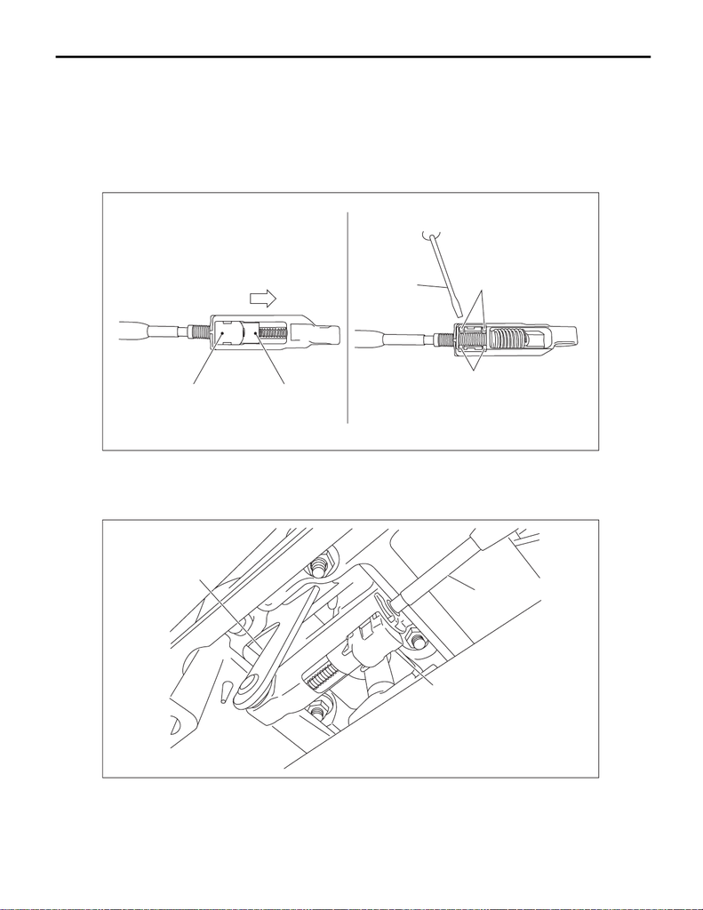

CS-107

MT Gear Select Cable

CONTROL SYSTEMS

6) Slide the slider (green) in the direction of the arrow and release the lock piece (pink) by using flat tip screw-

driver etc.

CAUTION:

Lock piece is easily damaged for the resin. When the lock piece is broken, replace the new MT gear

select cable.

NOTE:

Rotate the MT gear select cable to 180 degrees, slide the slider in the direction of the arrow and push the

claw of lock piece.

7) Connect the MT gear select cable to the select lever, with the lock piece released.

(A) Slider (C) Claw (D) Flat tip screwdriver

(B) Lock piece

(A) Lock piece (B) Select lever (C) MT gear select cable

CS-01170

(B)

(D)

(C)

(C)

(A)

CS-01171

(A)

(C)

(B)

15WRX_STI_US_EN.book 107 ページ ２０１５年２月１３日 金曜日 午前１１時２０分

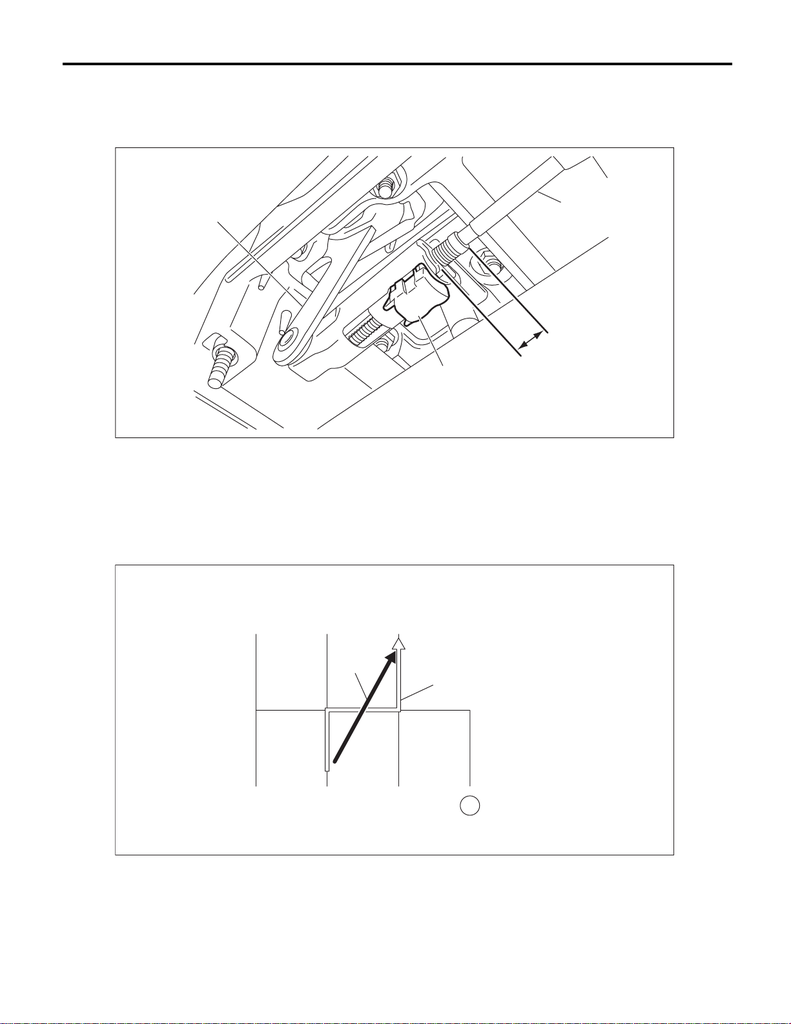

CS-108

MT Gear Select Cable

CONTROL SYSTEMS

8) Move the shift lever to the reverse side, keep the exposed length (a) of MT gear select cable to 11 mm (0.4

in), and push the lock piece.

NOTE:

Pull up the slider of the gear shift lever assembly, move to the Rev side.

9) Shift to 5th ←→ 6th and Rev, and check for stuck.

10) Check that the shift lever can move along the cranking line when operating the lever from 4th to 5th gear

with a load applied toward the 6th gear.

(a) Exposed length 11 mm (0.4 in)

(A) Lock piece (B) Select lever (C) MT gear select cable

(A) Cranking operation (B) Load direction

CS-01172

(A)

(B)

(C)

(a)

CS-01585

1

2

3

4

5

6R

(B)

(A)

15WRX_STI_US_EN.book 108 ページ ２０１５年２月１３日 金曜日 午前１１時２０分

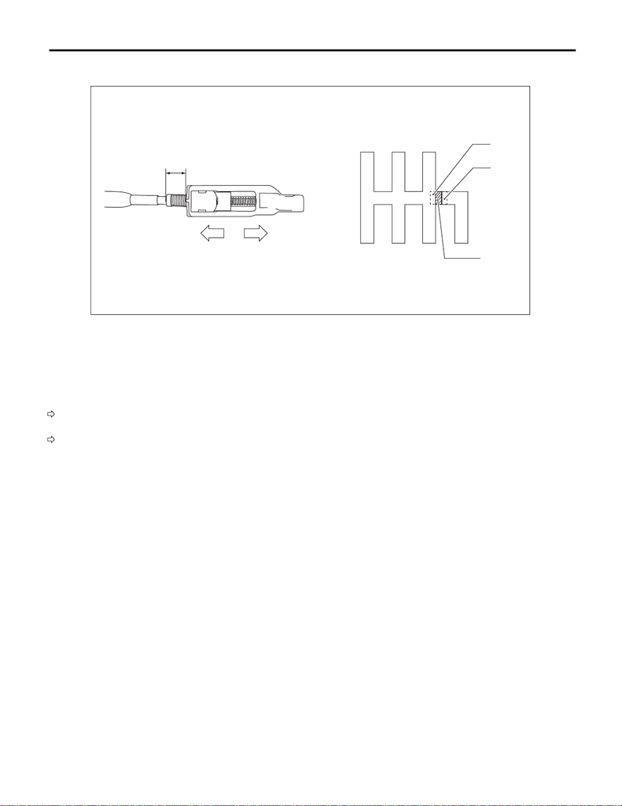

CS-109

MT Gear Select Cable

CONTROL SYSTEMS

11) If the shifting operation is not smooth, readjust the exposed length (a) of MT gear select cable by referring

to the following figure.

• If the shift cannot be inserted to push the reverse lock bracket 5th and 6th.

Extend the exposed length (a) of MT gear select cable.

• When operate the select lever to 4th → 5th, it cannot be operated at select lever crank line.

Shorten the exposed length (a) of MT gear select cable.

NOTE:

If it cannot adjust, replace the MT gear select cable.

12) Adjust the detent of the MT gear shift lever. <Ref. to CS-82, ADJUSTMENT, MT Gear Shift Lever.>

13) If no fault is found in the shift and select operation, restore the vehicle.

(a) Exposed length of MT gear select

cable

(A) Extend direction of exposed

length of MT gear select cable

(B) Shorten direction of exposed

length of MT gear select cable

(C) Specification of exposed length

(a)

CS-01173

1st

2nd

3rd

4th

5th

6th Rev

(a)

(B) (A)

(A)

(C)

(B)

15WRX_STI_US_EN.book 109 ページ ２０１５年２月１３日 金曜日 午前１１時２０分